# Power Analyses in Psychophysics

Björn Jörges

1/31/2020

*Introduction*

The so-called reproducibility crisis has shaken Psychology to the core. Many effect that the scientific community had deemed established, could not be reproduced in highly powered replication studies. Among these are, prominently, Ego Depletion (@Hagger2016, but see also @Dang) and Terror Management Theory (@Klein2019). @Klein2016 tested a whole series of effects, some of which were not reproduced at all, and some of which were reproduced in terms of statistical significance, but with smaller effect sizes. Different reasons for the lack of reproducibility have been suggested: wide-spread p-hacking, Hypothesizing After Results are Known (“HARKing”), publication bias, lacking power and lacking theory.

Interestingly, Cognitive Psychology, and more specifically Cognitive Psychology that relies on psychophysical methods, has generated less attention in terms of the reproducibility of its results. @Hesse1986 compared different psychophysical methods along criteria such as threshold estimates, efficiency (that is, how many trials it takes to achieve reliable results) and their reproducibility in the auditory domain. The reproducibility in the psychophysical measurement of pain sensations has received some attention (@Rosier, @Nilsson).

**Statistical Specifics of Psychophysics**

**Different Approaches to Null Hypothesis Testing**

Furthermore, there are different established ways of analyzing results. Classically, pychometric functions (Cummulative Gaussian or Weibull functions) are fitted for each condition and participant to obtain the Points of Subjective Equality (PSEs) and Just Noticeable Differences (JNDs). This yields one data point per subject and condition, over which a t.test or an ANOVA is performed to test for statistical significance between conditions. This approach neglects that each PSE and JND is based on a large number of trials and thus fails to account for the added reliability of the measures provided. Depending on the experimental design, this approach sacrifices vast amounts of statistical power. As a solution, @Moscatelli2012 have suggested the use of General Linear Mixed Modelling (GLMM). GLMM allows to fit population parameters across all data, while still taking into account that responses within each condition and participant are correlated more strongly than across conditions and participants. In the following, we will estimate power for both types of analyses, to quantify how much power is lost with the two-level approach.

Not being reproduced could also mean shoddy design in follow-up, and what about equivalence testing?

**Information Needed**

This method requires you to provide estimates of all relevant parameters. Some pertain to the stimuli, some can be taken from the literature, and some have to be estimated.

*ID* is a vector containing one ID for each subject we want to simulate.

*ConditionOfInterest* is a vector containing IDs for a binary categorical variable related to the main hypothesis of the experiment. For example: Is there a pictorial background scene?

*StandardValues* is a vector containing values for a categorial variable that serves as comparison stimuli. It can contain one value if you want to determine PSEs/JNDs for only one stimulus intensity, but typically you will have several, e. g. when you want to diversify your stimuli to show that a certain effect is not tied to one specific stimulus strength.

*reps* is a vector containing an ID for each trial, the maximum number being the average number of trials we expect for any given staircase.

*PSE_Difference* is a value that indicates the percentage to which the PSEs differ between test and standard condition. It can be zero if the condition of interest is not expected to influence PSEs.

*JND_Difference* is a value that indicates the percentage to which the JNDs differ between test and standard condition. It can be zero if the condition of interest is not expected to influence JNDs.

*Mean_Standard* is the Mean of the psychometric function expected for the standard condition. In many cases, this is the stimulus strength of the comparison stimulus.

*Multiplicator_SD_Standard* is a multiplicator that transforms Weber Fractions or JNDs from the literature into standard deviations for each comparison stimulus.

*SD_ResponseFunction* further describes the describes the function the stimulus strengths are chosen from. For normal distributions, this value corresponds to its standard deviation; for Cauchy distributions, this corresponds to its scale; and for uniform distributions, this corresponds to the range of values tested.

```r
ID = paste0("s",1:5)
ConditionOfInterest = c(0,1)
StandardValues = c(6.6, 8, 10)
reps = seq(1,55,1)
PSE_Difference = 1/8
JND_Difference = 1/3
PSE_Standard = StandardValues
Multiplicator_SD_Standard = 0.108
SD_Standard = StandardValues*Multiplicator_SD_Standard
Type_ResponseFunction = "Cauchy"
SD_ResponseFunction = 0.06
```

Next, we simulate one whole data set based on the above values. We first create a data frame with one row for each trial, that is a total of length(ID) x length(ConditionOfInterst) x length(StandardValues) x length(reps) rows.

```r
  Psychometric = expand.grid(ID=ID, ConditionOfInterest=ConditionOfInterest, StandardValues=StandardValues, reps = reps)
```

Then, we draw multiplicators for PSEs and JNDs per subject, accounting for between-subject differences in biases and precision.

```r
  Psychometric = Psychometric %>%
    group_by(ID) %>%#
    mutate(PSE_Factor_ID = rnorm(1,1,0.1), #how much variability is in the means of the psychometric functions between subjects?
           SD_Factor_ID = rnorm(1,1,0.1)) #how much variability is in the standard deviations of the psychometric functions between subjects?
```

Next, we simulate means and standard deviations of the psychometric functions for each condition and we add between-subject variability. The following lines take the standard PSEs (PSE_Standard) and standard deviations (SD_Standard) as baseline and add the PSE and JND difference in trials assigned to the test condition.

```r
  Psychometric = Psychometric %>%
    mutate(
      Mean = (StandardValues + (ConditionOfInterest==1)*StandardValues*PSE_Difference),
      SD = abs(SD_Standard + (ConditionOfInterest==1)*SD_Standard*JND_Difference))
```

Now, we multiply in the between-subject variability.

```r
  Psychometric = Psychometric %>%
    mutate(
      Mean = Mean*PSE_Factor_ID,
      SD = SD*SD_Factor_ID)
```

Next, we draw the stimulus strengths likely to be presented in our experiment. As mentioned above, this varies depending on the way the experiment is controlled. For staircase procedure, the responses are more akin to a normal distribution with relatively low standard deviations or to Cauchy distributions with equally low scales. For the method of constant stimuli, the responses are uniformly distributed across 5 to 9 values around the standard stimulus strength. We then use these multipliers (“staircase_factor”) to compute the test stimulus strengths presented in the experiment (“Presented_TestStimulusStrength”). Lastly, we compute the difference between test stimulus and standard stimulus for each trial (“Difference”).

```r
if (Type_ResponseFunction == "normal"){

  Psychometric = Psychometric %>%
  mutate(
      staircase_factor = pnorm(length(reps),1,SD_ResponseFunction))

} else if (Type_ResponseFunction == "Cauchy"){

  Psychometric = Psychometric %>%
  mutate(
      staircase_factor = rcauchy(length(reps),1,SD_ResponseFunction))

#} else if (Type_ResponseFunction == "uniform"){
#
#  Psychometric = Psychometric %>%
#  mutate(
#      staircase_factor = seq(SD_ResponseFunction[1],SD_ResponseFunction[2],(SD_ResponseFunction[2]-SD_ResponseFunc#tion[1]/6)))

} else{

  print("distribution not valid")

}

Psychometric = Psychometric %>%
  mutate(
      staircase_factor = rcauchy(length(reps),1,SD_ResponseFunction),
      Presented_TestStimulusStrength = Mean*staircase_factor,
      Difference = Presented_TestStimulusStrength - StandardValues)
```

Then, we compute the the probability on each trial to judge the test stimulus intensity higher (e. g. the test stimulus was faster, brighter, longer, …) by feeding the simulated test stimulus strengths in a cummulative Gaussian with the mean and the standard deviations calculated above. We then use this value (“AnswerProbability”) to simulate binary answers (“Answer”) by feeding the probabilities into a bernoulli function.

```r
Psychometric = Psychometric %>%
  mutate(
      AnswerProbability = pnorm(Presented_TestStimulusStrength,Mean,SD),

      ##get binary answers ("Test was stronger" yes/no) from probabilities for each trial
      Answer = as.numeric(rbernoulli(length(AnswerProbability),AnswerProbability))
    )
```

As a next step, we bring the data into the format necessary for the glmer() function: We first remove extreme outliers (e. g. by a simple criterion such as excluding trials in which the difference between test and standard stimulus was higher than half the standard stimulus strength). Then, we compute the number of “Test stimulus intensity was higher” responses for each Condition and difference between test and comparison stimulus strength and the number of total observerations for each condition and difference in intensities.

Now, we can inspect these psychometric functions visually to verify whether the values chosen above give rise to the expected psychometric functions in terms of PSE and slopes. As is usual for psychometric functions, we have the difference in stimulus strength between test and comparison on the x axis, the probability to choose the test stimulus as stronger on the y axis. The Condition of Interest is color-coded in blue, while the baseline condition is color-coded in red.The facets correspond to IDs and different standard stimulus strengths, respectively.

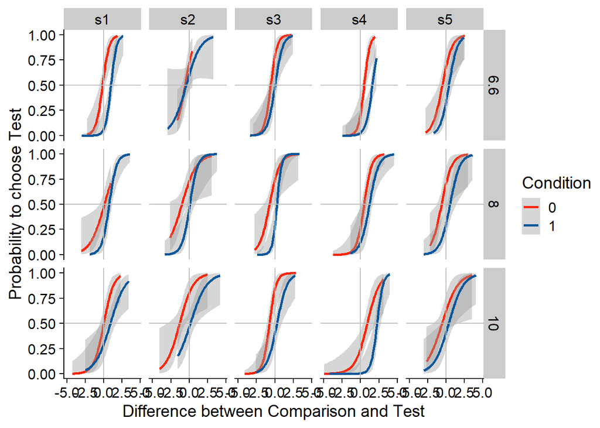

```r
ggplot(Psychometric, aes(Difference, Answer, color = as.factor(ConditionOfInterest))) +
  binomial_smooth() +
  facet_grid(StandardValues~ID) +
  geom_vline(xintercept = 0, color = "grey") +
  geom_hline(yintercept = 0.5, color = "grey") +
  xlab("Difference between Comparison and Test") +
  ylab("Probability to choose Test") +
  scale_color_manual(name = "Condition",
                     values = c(Red,BlauUB))
```

Next, we establish the statistical model we will use to test our hypotheses. Following (Moscatelli 2012), we use generalized linear mixed models for this purpuse. For differences in PSEs in our simulated data set, this model would look like the following:

```r
mod1 = glmer(cbind(Yes, Total - Yes) ~ ConditionOfInterest + (Difference  | ID)  + (Difference  | StandardValues),
               family = binomial(link = "probit"),
               data = Psychometric,
               nAGQ = 0,
               control = glmerControl(optimizer = "nloptwrap"))
```

We then establish a comparison model, corresponding in the next simpler model without the variable of interest:

```r
mod2 = glmer(cbind(Yes, Total - Yes) ~ (Difference  | ID) + (Difference  | StandardValues),
               family = binomial(link = "probit"),
               data = Psychometric,
               nAGQ = 0,
               control = glmerControl(optimizer = "nloptwrap"))
```

Finally, we compare both models by means of the anova() function.

```r
anova(mod1,mod2)
```

```
## Data: Psychometric
## Models:
## mod2: cbind(Yes, Total - Yes) ~ (Difference | ID) + (Difference | StandardValues)
## mod1: cbind(Yes, Total - Yes) ~ ConditionOfInterest + (Difference |
## mod1:     ID) + (Difference | StandardValues)
##      Df  AIC    BIC  logLik deviance  Chisq Chi Df Pr(>Chisq)
## mod2  7 1848 1885.4 -917.02     1834
## mod1  8 1750 1792.7 -866.99     1734 100.06      1  < 2.2e-16 ***
## ---
## Signif. codes:  0 '***' 0.001 '**' 0.01 '*' 0.05 '.' 0.1 ' ' 1
```

```r
summary(mod1)
```

```
## Generalized linear mixed model fit by maximum likelihood (Adaptive
##   Gauss-Hermite Quadrature, nAGQ = 0) [glmerMod]
##  Family: binomial  ( probit )
## Formula: cbind(Yes, Total - Yes) ~ ConditionOfInterest + (Difference |
##     ID) + (Difference | StandardValues)
##    Data: Psychometric
## Control: glmerControl(optimizer = "nloptwrap")
##
##      AIC      BIC   logLik deviance df.resid
##   1750.0   1792.7   -867.0   1734.0     1530
##
## Scaled residuals:
##     Min      1Q  Median      3Q     Max
## -4.2883 -0.8286 -0.0452  0.8164  8.2616
##
## Random effects:
##  Groups         Name        Variance  Std.Dev. Corr
##  ID             (Intercept) 2.696e-01 0.519191
##                 Difference  5.955e-03 0.077171 -0.11
##  StandardValues (Intercept) 1.374e-05 0.003707
##                 Difference  8.608e-01 0.927788 0.51
## Number of obs: 1538, groups:  ID, 5; StandardValues, 3
##
## Fixed effects:
##                     Estimate Std. Error z value Pr(>|z|)
## (Intercept)          0.28519    0.23873   1.195    0.232
## ConditionOfInterest -0.85891    0.08912  -9.638   <2e-16 ***
## ---
## Signif. codes:  0 '***' 0.001 '**' 0.01 '*' 0.05 '.' 0.1 ' ' 1
##
## Correlation of Fixed Effects:
##             (Intr)
## CndtnOfIntr -0.167
```

If the test model is significantly (p < 0.05) better than the comparison model, the test variable has a relevant impact on the responses.

For differences in JNDs in our simulated data set, this procedure would look like the following:

```r
  mod1 = glmer(cbind(Yes, Total - Yes) ~ as.factor(ConditionOfInterest)*Difference + (Difference  | ID) + (Difference  | StandardValues),
               family = binomial(link = "probit"),
               data = Psychometric,
               nAGQ = 0,
               control = glmerControl(optimizer = "nloptwrap"))
  mod2 = glmer(cbind(Yes, Total - Yes) ~ as.factor(ConditionOfInterest) + Difference + (Difference  | ID) + (Difference  | StandardValues),
               family = binomial(link = "probit"),
               data = Psychometric,
               nAGQ = 0,
               control = glmerControl(optimizer = "nloptwrap"))
```

We again use an ANOVA to test whether the test model is better than the comparison model:

```r
anova(mod1,mod2)
```

```
## Data: Psychometric
## Models:
## mod2: cbind(Yes, Total - Yes) ~ as.factor(ConditionOfInterest) + Difference +
## mod2:     (Difference | ID) + (Difference | StandardValues)
## mod1: cbind(Yes, Total - Yes) ~ as.factor(ConditionOfInterest) * Difference +
## mod1:     (Difference | ID) + (Difference | StandardValues)
##      Df    AIC    BIC logLik deviance Chisq Chi Df Pr(>Chisq)
## mod2  9 1740.2 1788.2 -861.1   1722.2
## mod1 10 1742.2 1795.6 -861.1   1722.2     0      1          1
```

```r
summary(mod1)
```

```
## Generalized linear mixed model fit by maximum likelihood (Adaptive
##   Gauss-Hermite Quadrature, nAGQ = 0) [glmerMod]
##  Family: binomial  ( probit )
## Formula:
## cbind(Yes, Total - Yes) ~ as.factor(ConditionOfInterest) * Difference +
##     (Difference | ID) + (Difference | StandardValues)
##    Data: Psychometric
## Control: glmerControl(optimizer = "nloptwrap")
##
##      AIC      BIC   logLik deviance df.resid
##   1742.2   1795.6   -861.1   1722.2     1528
##
## Scaled residuals:
##     Min      1Q  Median      3Q     Max
## -4.0016 -0.8282 -0.0441  0.8184  8.6658
##
## Random effects:
##  Groups         Name        Variance Std.Dev. Corr
##  ID             (Intercept) 0.274980 0.52439
##                 Difference  0.004654 0.06822  -0.27
##  StandardValues (Intercept) 0.000000 0.00000
##                 Difference  0.015093 0.12286   NaN
## Number of obs: 1538, groups:  ID, 5; StandardValues, 3
##
## Fixed effects:
##                                            Estimate Std. Error z value
## (Intercept)                                 0.29000    0.24135   1.202
## as.factor(ConditionOfInterest)1            -0.85739    0.08934  -9.597
## Difference                                  0.93884    0.10655   8.812
## as.factor(ConditionOfInterest)1:Difference -0.04945    0.08528  -0.580
##                                            Pr(>|z|)
## (Intercept)                                   0.230
## as.factor(ConditionOfInterest)1              <2e-16 ***
## Difference                                   <2e-16 ***
## as.factor(ConditionOfInterest)1:Difference    0.562
## ---
## Signif. codes:  0 '***' 0.001 '**' 0.01 '*' 0.05 '.' 0.1 ' ' 1
##
## Correlation of Fixed Effects:
##             (Intr) as.(COI)1 Dffrnc
## as.fc(COI)1 -0.161
## Difference  -0.005 -0.291
## as.(COI)1:D -0.060 -0.057    -0.452
```

```r
SimulatePsychometricFunction_Staircase = function(ID, ConditionOfInterest, StandardValues, reps, PSE_Difference, JND_Difference, Mean_Standard, SD_Standard, SD_ResponseFunction){
  Psychometric = expand.grid(ID=ID, ConditionOfInterest=ConditionOfInterest, StandardValues=StandardValues, reps = reps)

  Psychometric = Psychometric %>%
    group_by(ID) %>%#
    mutate(PSE_Factor_ID = rnorm(1,1,0.1),
           SD_Factor_ID = rnorm(1,1,0.1))

  Psychometric = Psychometric %>%
    mutate(
      Mean = (StandardValues + (ConditionOfInterest==1)*StandardValues*PSE_Difference)*PSE_Factor_ID,
      SD = abs((SD_Standard + (ConditionOfInterest==1)*SD_Standard*JND_Difference)*SD_Factor_ID),
      staircase_factor = rcauchy(length(reps),1,SD_ResponseFunction),
      Presented_TestStimulusStrength = Mean*staircase_factor,
      Difference = Presented_TestStimulusStrength - StandardValues,
      AnswerProbability = pnorm(Presented_TestStimulusStrength,Mean,SD),
      Answer = as.numeric(rbernoulli(length(AnswerProbability),AnswerProbability))
    )

  Psychometric = Psychometric %>%
    filter(abs(Difference) < 0.5*abs(Mean)) %>%
    group_by(ID,ConditionOfInterest,StandardValues,Difference) %>%
    mutate(Yes = sum(Answer==1),
           Total = length(ConditionOfInterest))

  Psychometric
}

Analyze_Pychometric_Accuracy = function(Psychometric){

  TimeBeginning = Sys.time()

  mod1 = glmer(cbind(Yes, Total - Yes) ~ ConditionOfInterest + (Difference  | ID)  + (Difference  | StandardValues),
               family = binomial(link = "probit"),
               data = Psychometric,
               nAGQ = 0,
               control = glmerControl(optimizer = "nloptwrap"))

  mod2 = glmer(cbind(Yes, Total - Yes) ~ (Difference  | ID) + (Difference  | StandardValues),
               family = binomial(link = "probit"),
               data = Psychometric,
               nAGQ = 0,
               control = glmerControl(optimizer = "nloptwrap"))

  print(TimeBeginning - Sys.time()) ###This is two show how long each iteration takes

  p = anova(mod1,mod2)$`Pr(>Chisq)`[2] ##Model 1 beats model 2
  print(p)

  p
}

Analyze_Pychometric_Precision = function(Psychometric){

  TimeBeginning = Sys.time()

  mod1 = glmer(cbind(Yes, Total - Yes) ~ as.factor(ConditionOfInterest)*Difference + (Difference  | ID) + (Difference  | StandardValues),
               family = binomial(link = "probit"),
               data = Psychometric,
               nAGQ = 0,
               control = glmerControl(optimizer = "nloptwrap"))
  mod2 = glmer(cbind(Yes, Total - Yes) ~ as.factor(ConditionOfInterest) + Difference + (Difference  | ID) + (Difference  | StandardValues),
               family = binomial(link = "probit"),
               data = Psychometric,
               nAGQ = 0,
               control = glmerControl(optimizer = "nloptwrap"))

  print(TimeBeginning - Sys.time())  ###This is two show how long each iteration takes

  p = anova(mod1,mod2)$`Pr(>Chisq)`[2] ##Model 1 beats model 2

  print(p)

  p
}
```

Now, we determine for how many subjects we want to simulate the power.

```r
#NumbersOfSubjects = c(10,12,14,16,18,20) #for how many subjects are we simulating the power?
NumbersOfSubjects = c(2)
```

Then, we execute the above method “nIterations” times for each number of subjects specified above, both for precision and accuracy by using the replicate() function from the R core package.

```r
PowerPerN_Precision = c()
plots_Precision = data.frame()

for (i in NumbersOfSubjects){
  ID = paste0("s",1:i)

  Power_Precision = c()

  nIterations = 1 #how many data frames should we simulate per number of subjects? more data frames makes for a more reliable estimate of the power

  out <- replicate(nIterations, { #this function performs the number of iterations indicated above and stores the result for each in "out"
    Analyze_Pychometric_Precision(SimulatePsychometricFunction_Staircase(ID, ConditionOfInterest, StandardValues, reps, PSE_Difference, JND_Difference, Mean_Standard, SD_Standard, SD_ResponseFunction))})

  outout = data.frame(pvalue = out,N_Subjects = paste(i,"participants"))
  plots_Precision = rbind(plots_Precision,outout)

  Power_Precision = mean(out < 0.05) ###Power is the times the difference between the two models is significant

  PowerPerN_Precision = c(PowerPerN_Precision,Power_Precision) ###This is a vector with the power for each n for the JNDs

  paste0("For ", i, " subjects: ", Power_Precision) #gives an estimate of the power for each n
}
```

```
## Time difference of -0.33705 secs
## [1] 0.04644401
```

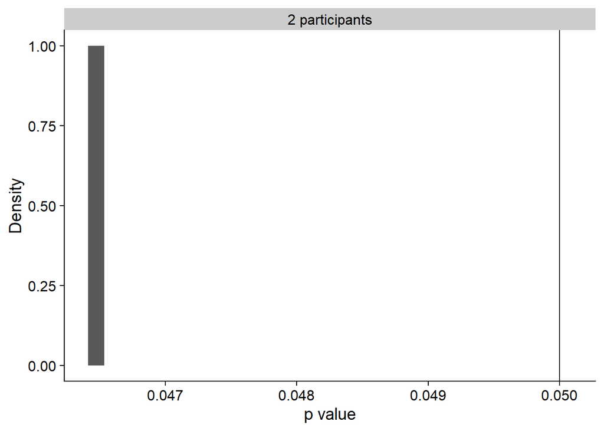

```r
ggplot(plots_Precision,aes(pvalue)) +
  geom_histogram() +
  facet_wrap(.~N_Subjects) +
  xlab("p value") +
  ylab("Density") +
  geom_vline(xintercept = 0.05)
```

```r
PowerPerN_Accuracy = c()
plots_Accuracy = data.frame()

for (i in NumbersOfSubjects){
  ID = paste0("s",1:i)

  Power_Accuracy = c()

  nIterations = 1 #how many data frames should we simulate per number of subjects? more data frames makes for a more reliable estimate of the power

  out2 <- replicate(nIterations, { #this function performs the number of iterations indicated above and stores the result for each in "out2"
    Analyze_Pychometric_Accuracy(SimulatePsychometricFunction_Staircase(ID, ConditionOfInterest, StandardValues, reps, PSE_Difference, JND_Difference, Mean_Standard, SD_Standard, SD_ResponseFunction))})

  outout = data.frame(pvalue = out2,N_Subjects = paste(i,"participants"))
  plots_Accuracy = rbind(plots_Accuracy,outout)

  Power_Accuracy = mean(out2 < 0.05) ###Power is the times the difference between the two models is significant

  PowerPerN_Accuracy = c(PowerPerN_Accuracy,Power_Accuracy) ###This is a vector with the power for each n for the PSEs

  paste0("For ", i, " subjects: ", Power_Accuracy) #prints estimate of the power for each n
}
```

```
## Time difference of -0.841866 secs
## [1] 1.374664e-08
```

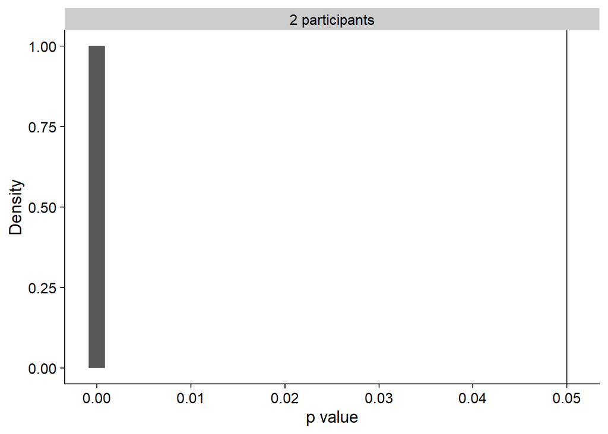

```r
ggplot(plots_Accuracy,aes(pvalue)) +
  geom_histogram() +
  facet_wrap(.~N_Subjects) +
  xlab("p value") +
  ylab("Density") +
  geom_vline(xintercept = 0.05)
```